# Tarea 2 Estadística Inferencial - Equipo 9

Fernando Carmona, Amaru Monje, Cristóbal Flores

2025-03-27

```r
library(dplyr)
library(ggpubr)
library(plotly)
library(knitr)
library(kableExtra)
```

## Preguntas Equipo 9:

### El conjunto de datos posee las siguientes variables:

Tabla 1. Descripción general de variables

| Nombre_de_variable | Tipo.de.Variable | Descripción |
| --- | --- | --- |
| Id | Identificador | Identificador único para cada atleta |
| Raza | Categórica | Raza del atleta |
| Previo | Numérica | Mejor tiempo registrado por el atleta antes de ingresar al programa de entrenamiento (En segundos) |
| Posterior | Numérica | Mejor tiempo registrado por el atleta después de los primeros 6 meses del programa de entrenamiento (En segundos) |

## Pregunta 1:

### El Comité Olímpico cree que el mejor tiempo medio de los atletas de raza blanca después de ingresar al programa de entrenamiento es superior a 13,2 segundos. ¿Soportan los datos esta afirmación?

Hipotesis nula: El mejor tiempo medio de los atletas de raza blanca después de ingresar al programa de entrenamiento es igual a 13.2

Hipotesis alternativa: El mejor tiempo medio de los atletas de raza blanca después de ingresar al programa de entrenamiento es superior a 13.2 segundos.

Prueba a utilizar: la prueba t student es la mas adecuada, pues las observaciones son menores a 30 y no conocemos su desviación estandar. se usará un nivel de significancia de 0.05.

Condiciones para la prueba t student:

1. Las observaciones son independientes entre sí: es evidente que los tiempos de los atletas son independientes entre sí
2. Las observaciones provienen de una población normalmente distribuida

```r
#Filtrar los datos de los atletas de raza blanca
datos_blancos <- data[data$Raza == "Blanca",]
#Verificar distribución muestral usando la prueba de normalidad de Shapiro-Wilk
shapiro.test(datos_blancos$Posterior)
```

```
##
##  Shapiro-Wilk normality test
##
## data:  datos_blancos$Posterior
## W = 0.94734, p-value = 0.2008
```

El p-value es mayor a 0.05, por lo que no se rechaza la hipotesis nula de normalidad, lo que se reforzá con el siguiente gráfico:

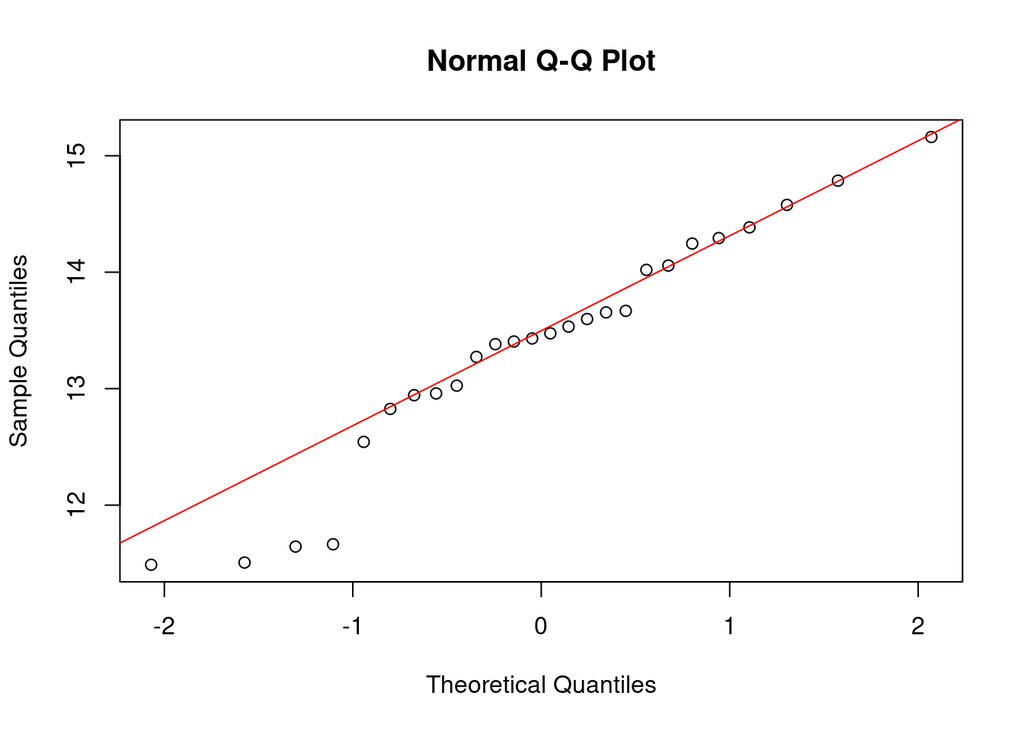

```r
# QQ-plot
qqnorm(datos_blancos$Posterior)
qqline(datos_blancos$Posterior, col = "red")  # Agregar la línea de referencia
```

Prueba t student para comparar la media de una muestra con un valor de referencia

```r
t.test(datos_blancos$Posterior, mu = 13.2, alternative = "greater")
```

```
##
##  One Sample t-test
##
## data:  datos_blancos$Posterior
## t = 0.85525, df = 25, p-value = 0.2003
## alternative hypothesis: true mean is greater than 13.2
## 95 percent confidence interval:
##  13.03327      Inf
## sample estimates:
## mean of x
##  13.36719
```

por lo tanto, dado que el p-value es mayor que 0.05, no existe evidencia suficiente para descartar la hipotesis nula, es decir, la poblacion si podria tener una media de 13.2, dado que esta dentro del intervalo de confianza.

## Pregunta 2:

### ¿Sugieren los datos que la mejor marca de los atletas de raza oriental se reduce en promedio más de 5,2 segundos tras el entrenamiento?

Hipótesis nula: La mejor marca de los atletas de raza oriental no se redujo en promedio más de 5,2 segundos, tras el entrenamiento.

Ho: Mpto < 5,2s

Hipótesis alternativa: La mejor marca de los atletas de raza oriental se redujo en promedio por más de 5,2 segundos, tras el entrenamiento.

Ha: Mpto >= 5,2s

Para responder está pregunta primero conseguimos los datos.

```r
orientales <- data[data$Raza == "Oriental",]

ans_orientales <- orientales[,3]

des_orientales <- orientales[,4]
```

El número de datos de está muestra es menor a 30, por lo cual procedemos a revisar las condiciones de t test, las cuales son:

1. Las observaciones son independientes entre sí: es evidente que los tiempos de los atletas son independientes entre sí
2. Las observaciones provienen de una población normalmente distribuida

Ahora procedemos a comprobar si la distribución de datos sigue una distribución normal, esto con shapiro.test

```r
oa.test <- shapiro.test(ans_orientales)
oa.test
```

```
##
##  Shapiro-Wilk normality test
##
## data:  ans_orientales
## W = 0.98354, p-value = 0.932
```

Como tenemos un p-value > 0,05, comprobamos que si se sigue una distribución normal, lo cual se resaltá con el siguiente gráfico

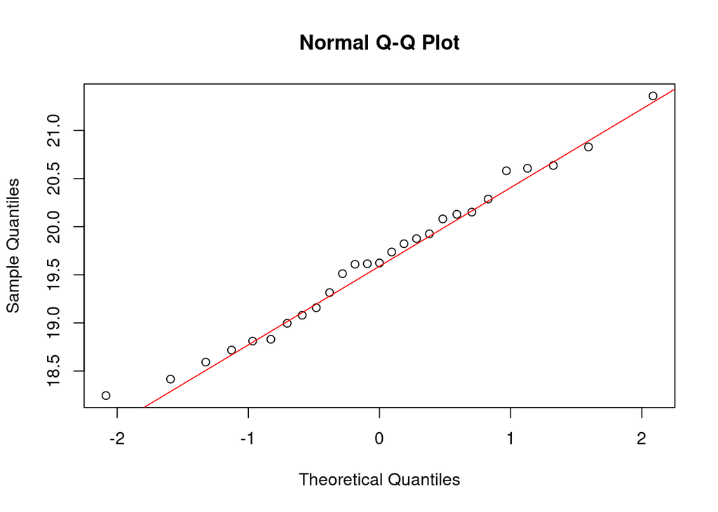

```r
# QQ-plot
qqnorm(ans_orientales)
qqline(ans_orientales, col = "red")  # Agregar la línea de referencia
```

Para poder utilizar t test con dos variables, ambas tienen que cumplir las condiciones antes mencionadas, por lo que repetimos shapiro.test para los tiempos después del entrenamiento

```r
od.test <- shapiro.test(des_orientales)
od.test
```

```
##
##  Shapiro-Wilk normality test
##
## data:  des_orientales
## W = 0.9689, p-value = 0.573
```

Tenemos un p-value > 0,05, comprobamos que si se sigue una distribución normal, lo cual se resaltá con el siguiente gráfico

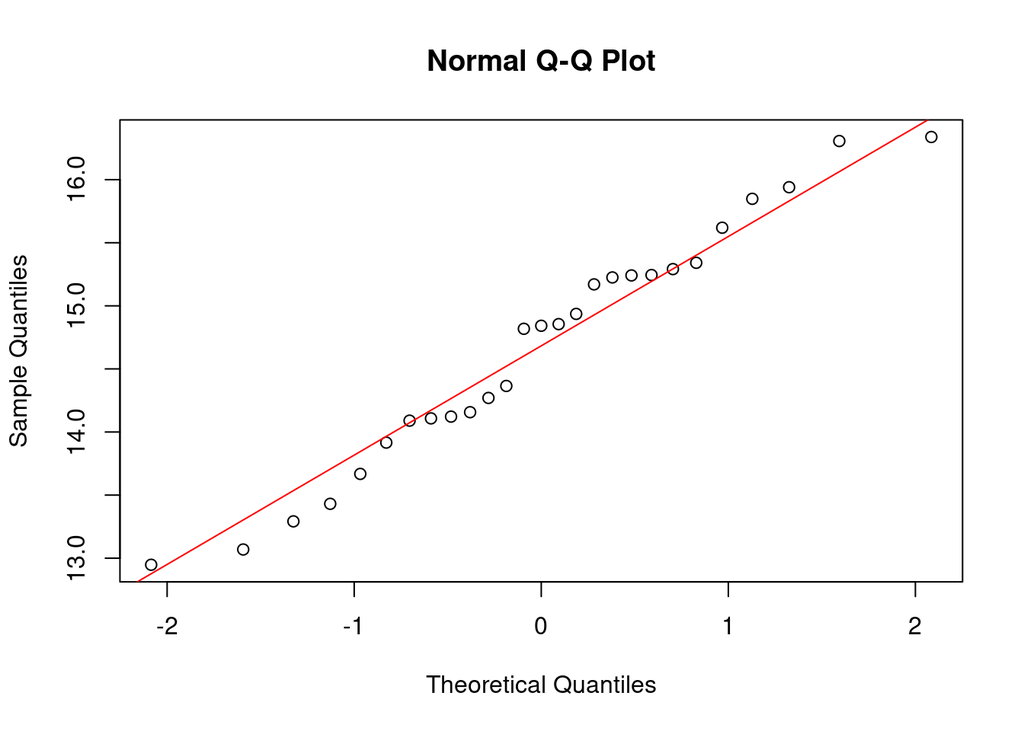

```r
# QQ-plot
qqnorm(des_orientales)
qqline(des_orientales, col = "red")  # Agregar la línea de referencia
```

Como ambas muestras de datos tienen p > 0,05, podemos usar un t.test para muestras pareadas, podemos decir que estos datos son pareados, dado que, son los mismos atletas solo que en distintos tiempos, antes del entrenamiento y después. Por esto podemos decir que los resultados de antes del entrenamiento afectán al después, con esto comprobando que se trata de datos pareados:

```r
t.test(ans_orientales, des_orientales, paired = TRUE, alternative = "greater", mu = -5.2)
```

```
##
##  Paired t-test
##
## data:  ans_orientales and des_orientales
## t = 158.02, df = 26, p-value < 2.2e-16
## alternative hypothesis: true mean difference is greater than -5.2
## 95 percent confidence interval:
##  4.856744      Inf
## sample estimates:
## mean difference
##        4.966481
```

## Pregunta 3:

### ¿Es posible afirmar que, en promedio, los atletas de raza negra superan a los de raza blanca por 1,3 segundos después del entrenamiento?

Hipótesis nula: Los atletas de raza negra no superan a los de raza blanca por 1,3 segundos, después del entrenamineto.

Ho: tn - tb != 1,3s

Hipótesis alternativa: Los atletas de raza negra superan a los de raza blanca por 1,3 segundos, después del entrenamineto.

Ha: tn - tb = 1,3s

Para responder está pregunta primero conseguimos los datos.

```r
atl_neg <- data[data$Raza == "Negra",]

des_neg <- atl_neg[,4]

atl_bl <- data[data$Raza == "Blanca",]

des_bl <- atl_bl[,4]
```

El número de datos de está muestra es menor a 30, por lo cual procedemos a revisar las condiciones de t test, las cuales son:

1. Las observaciones son independientes entre sí: es evidente que los tiempos de los atletas son independientes entre sí
2. Las observaciones provienen de una población normalmente distribuida

Ahora procedemos a comprobar si la distribución de datos sigue una distribución normal, esto con shapiro.test

```r
n.test <- shapiro.test(des_neg)
n.test
```

```
##
##  Shapiro-Wilk normality test
##
## data:  des_neg
## W = 0.95201, p-value = 0.2225
```

Como tenemos un p-value > 0,05, comprobamos que si se sigue una distribución normal, lo cual se resaltá con el siguiente gráfico

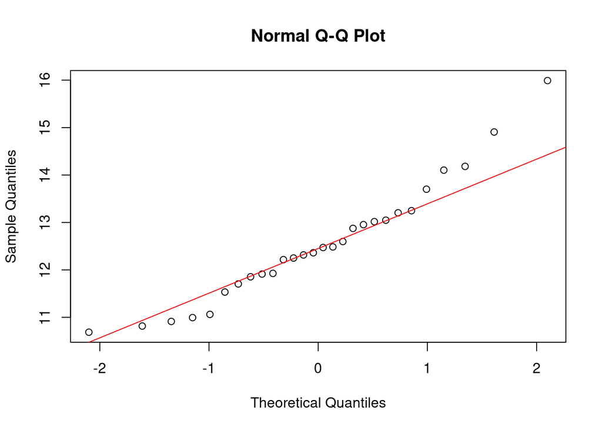

```r
# QQ-plot
qqnorm(des_neg)
qqline(des_neg, col = "red")  # Agregar la línea de referencia
```

Para poder utilizar t test con dos variables, ambas tienen que cumplir las condiciones antes mencionadas, por lo que repetimos shapiro.test para los tiempos después del entrenamiento

```r
b.test <- shapiro.test(des_bl)
b.test
```

```
##
##  Shapiro-Wilk normality test
##
## data:  des_bl
## W = 0.94734, p-value = 0.2008
```

Tenemos un p-value > 0,05, comprobamos que si se sigue una distribución normal, lo cual se resaltá con el siguiente gráfico

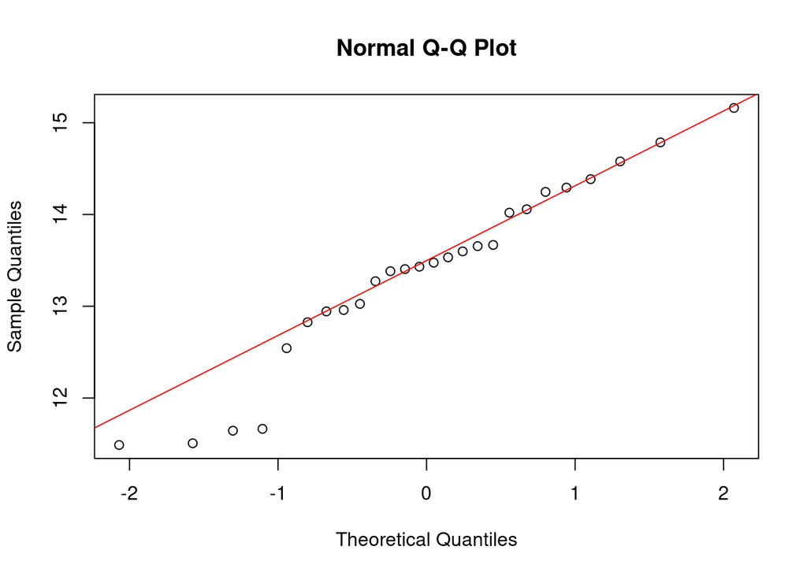

```r
# QQ-plot
qqnorm(des_bl)
qqline(des_bl, col = "red")  # Agregar la línea de referencia
```

Como ambas muestras de datos tienen p > 0,05, podemos usar un t.test para muestras no pareadas, podemos decir que estos datos no son pareados, dado que, son distintos atletas. Por esto podemos decir que los resultados del entrenamiento no afectán a los resultados entre ambas muestras, con esto comprobando que se trata de datos no pareados:

```r
t.test(des_neg, des_bl, alternative = "two.sided", mu = -1.3)
```

```
##
##  Welch Two Sample t-test
##
## data:  des_neg and des_bl
## t = 1.5616, df = 50.809, p-value = 0.1246
## alternative hypothesis: true difference in means is not equal to -1.3
## 95 percent confidence interval:
##  -1.4371895 -0.2025522
## sample estimates:
## mean of x mean of y
##  12.54732  13.36719
```

Dado que p > 0,05 no podemos descartar la hipótesis nula, por tanto no existe evidencia que los atletas negros superan a los atletas blancos por 1,3 segundos después del entrenamiento.

## Pregunta 4:

### ¿Será cierto que hay más atletas de raza blanca que redujeron sus mejores marcas en al menos 2,6 segundos que atletas de raza negra que lo hicieron en al menos 1,5 segundos?

Hipótesis nula ($H_0$): La proporción de atletas blancos que redujeron sus tiempos ≥ 2,6s es menor o igual que la proporción de atletas negros que redujeron ≥ 1,5s.

Hipótesis alternativa ($H_a$): La proporción de atletas blancos que redujeron sus tiempos ≥ 2,6s es mayor que la proporción de atletas negros que redujeron ≥ 1,5s.

Evaluamos normalidad de los datos con Shapiro-Wilk

```
##
##  Shapiro-Wilk normality test
##
## data:  diferenciaRazaNegra
## W = 0.9781, p-value = 0.8027
```

```
##
##  Shapiro-Wilk normality test
##
## data:  diferenciaRazaBlanca
## W = 0.95709, p-value = 0.3375
```

```
## Como los valores p-value de ambos test están sobre 0.05, comprobamos la normalidad de los datos para las diferencias de tiempos previos y posteriores para atletas de Raza Negra como para atletas de Raza Blanca.
```

#### Normal Q-Q Plot Diferencias en tiempo Raza Negra y Blanca

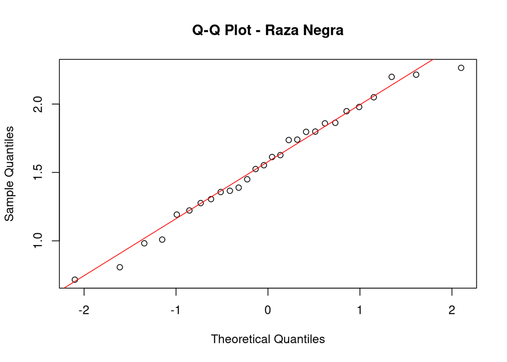

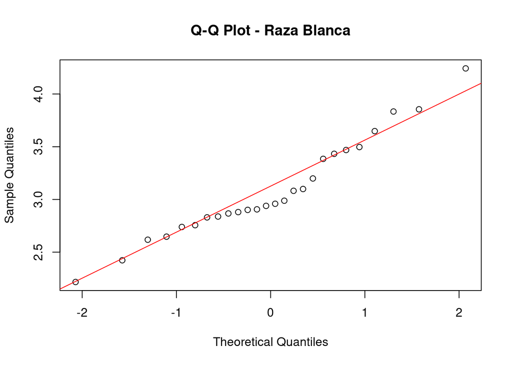

Prueba a utilizar: Método de Wilson, pues permite comparar las proporciones de los cambios en los tiempos de los atletas.

```
##
##  2-sample test for equality of proportions with continuity correction
##
## data:  c(total_redujo_bl, total_redujo_ne) out of c(total_blancos, total_negros)
## X-squared = 6.9462, df = 1, p-value = 0.0042
## alternative hypothesis: greater
## 95 percent confidence interval:
##  0.1383433 1.0000000
## sample estimates:
##    prop 1    prop 2
## 0.9230769 0.5714286
```

Puesto que el p-value es menor a 0.05 se rechaza la hipótesis nula para el rango de confianza solicitado. Por lo tanto, según el estudio realizado, es cierto que hay más atletas de raza blanca que redujeron sus tiempos en al menos 2,6 segundos que atletas de raza negra que redujeron sus tiempos en al menos 1,5 segundos.